# Entrega 5 - Reglas de Asociación

Minería de Datos

Andrés Campos Cuiña

12/04/2022

# Introducción

En primer lugar, definimos el directorio de trabajo:

```r
setwd("c:/Users/Andres/Google Drive/USC/MaBD/Mineria de Datos/Practicas/Practica5/")
```

En segundo lugar, cargamos las librerías necesarias:

```r
library(ggplot2)
library(gridExtra)
library(reshape)
library(arules)
library(arulesViz)
library(car)
```

# Ejercicios

## Ejercicio 1

**Examina el contenido de los ficheros titanic1 y titanic2.**

**1. ¿En qué formato están almacenados los datos en cada fichero?**

**2. Crea dos objetos llamados titanic.basket y titanic.single que contengan los datos de los ficheros anteriormente mencionados.**

**Apartado 1**

El fichero `titanic1` está almacenado en formato `basket`, ya que cada linea representa una transacción donde los *items* están separados por un caracter delimitador (en este caso un espacio en blanco).

En el fichero `titanic1` en cada línea aparece una transacción con cinco atributos, que son **clase**, **superviviente**, **sexo**, **edad** y **embarque**.

Por otra parte, el fichero `titanic2` está almacenado en formato `single`, ya que línea corresponde a un único *item* y cada línea tiene dos columnas, el **id** de la transacción y el atributo que se está representando en esa línea. Cada transacción se define, por lo tanto, como un conjunto de línea que tengan el mismo id.

Los atributos de las transacciones del fichero `titanic2` son los mismos que los del fichero `titanic1`.

**Apartado 2**

```r
titanic.basket <-
  read.transactions(
    "./data/titanic1",
    format = "basket",
    header=FALSE,
    rm.duplicates = TRUE,
    quote = "\""
  )

# Mostramos por pantalla
titanic.basket
```

```
## transactions in sparse format with
##  1043 transactions (rows) and
##  13 items (columns)
```

```r
titanic.single <-
  read.transactions(
    "./data/titanic2",
    format = "single",
    header=FALSE,
    cols = c(1, 2),
    rm.duplicates = TRUE,
    quote = "\""
  )

# Mostramos por pantalla
titanic.single
```

```
## transactions in sparse format with
##  1043 transactions (rows) and
##  13 items (columns)
```

## Ejercicio 2

**Lee el fichero `titanic.csv` y examina los atributos que tiene y el tipo de cada uno de ellos.**

**1. Elimina la columna `tarifa`, esa información la tenemos discretizada en el atributo `clase`.**

**2. Discretiza el atributo `edad` en tres categorías: `Child` (menor que 18), `Adult` (entre 18 y 65) y `Old` (mayor que 65).**

**3. Recodifica el atributo `superviviente` a `Si` para el valor 1 y `No` para el valor 0.**

**4. Crea un objeto de la clase `transactions`, llamado `titanic.trans`, a partir del dataframe `titanic`.**

Lo primero será leer el fichero `titanic.csv` y ver los atributos que tiene y el tipo de cada uno de ellos.

```r
titanic <- read.csv(
  './data/titanic.csv',
  header=TRUE,
  sep = ';'
)

# Mostramos los atributos que tiene por pantalla
str(titanic)
```

```
## 'data.frame':    1043 obs. of  6 variables:
##  $ clase        : chr  "primera" "primera" "primera" "primera" ...
##  $ superviviente: int  1 1 0 0 0 1 1 0 1 0 ...
##  $ sexo         : chr  "mujer" "hombre" "mujer" "hombre" ...
##  $ edad         : chr  "29" "1" "2" "30" ...
##  $ tarifa       : chr  "211,337494" "151,550003" "151,550003" "151,550003" ...
##  $ embarque     : chr  "Southampton" "Southampton" "Southampton" "Southampton" ...
```

Como podemos ver hay 6 atributos, que son los siguiente:

- **clase**: de tipo char con tres valores posibles (primera, segunda y tercera).
- **superviviente**: de tipo int con dos valores posibles (0 y 1).
- **sexo**: de tipo char con dos valores posibles (mujer y hombre).
- **edad**: de tipo char (debería ser de tipo int).
- **tarifa**: de tipo char (debería ser de tipo numeric).
- **embarque**: de tipo char con tres valores posibles (Southampton, Cherbourg y Queenstown).

Antes de seguir, hacemos los cambios en el tipo de dato adecuados.

```r
# Cambiamos las comas por puntos para que la conversión se haga correctamente

# edad a numeric
titanic$edad <- as.numeric(sub(",", ".", titanic$edad, fixed = TRUE))
```

**Apartado 1**

```r
titanic$tarifa <- NULL
```

**Apartado 2**

```r
titanic$edad <-
  discretize(
    titanic$edad,
    method = "fixed",
    breaks = c(0, 18, 66, 123),
    labels = c("Child", "Adult", "Old"),
    ordered = TRUE
  )
```

**Apartado 3**

```r
titanic$superviviente <-
  as.factor(recode(titanic$superviviente, "0='No';1='Si'"))
```

**Apartado 4**

Antes de generar el objeto `titanic.trans` convertimos las columnas que siguen con tipo `char` a tipo `Factor`.

```r
titanic$clase <- as.factor(titanic$clase)
titanic$sexo <- as.factor(titanic$sexo)
titanic$embarque <- as.factor(titanic$embarque)
```

Ahora generamos el objeto `titanic.trans`,

```r
titanic.trans <- as(titanic, "transactions")

# Mostramos por pantalla
titanic.trans
```

```
## transactions in sparse format with
##  1043 transactions (rows) and
##  13 items (columns)
```

## Ejercicio 3

**Utilizando la función `write()` genera dos ficheros en formato `csv` denominados `titanic.basket` y `titanic.single`, cada uno conteniendo las transacciones en los formatos indicados en su nombre.**

```r
write(titanic.trans, file = "./output/titanic.basket", format = "basket")
write(titanic.trans, file = "./output/titanic.single", format = "single")
```

## Ejercicio 4

**Partiendo de la base de transacciones `titanic.trans` obtenida en el ejercicio 2.**

**1. Aplica las funciones `apriori()` y `eclat()` y genera los objetos `titanic.rules` y `titanic.eclat` respectivamente.**

**2. Indica cuáles son los valores de los parámetros por defecto.**

**3. Genera una tabla en R en la que en cada fila indique un valor real entre 0 y 1 (empezando por 0.1 y con incrementos de 0.1), el número de reglas generadas para un soporte igual a dicho número en la segunda columna y lo mismo pero para la confianza en la tercera columna. Para poder realizar esta cuestión hay que utilizar la función `length()` sobre el conjunto de reglas.**

**4. Representa gráficamente la tabla anterior.**

**5. Genera un conjunto de reglas de asociación para determinar qué items están relacionados con el sexo.**

**Apartado 1**

```r
titanic.rules <- apriori(titanic.trans)
```

```
## Apriori
##
## Parameter specification:
##  confidence minval smax arem  aval originalSupport maxtime support minlen
##         0.8    0.1    1 none FALSE            TRUE       5     0.1      1
##  maxlen target  ext
##      10  rules TRUE
##
## Algorithmic control:
##  filter tree heap memopt load sort verbose
##     0.1 TRUE TRUE  FALSE TRUE    2    TRUE
##
## Absolute minimum support count: 104
##
## set item appearances ...[0 item(s)] done [0.00s].
## set transactions ...[13 item(s), 1043 transaction(s)] done [0.00s].
## sorting and recoding items ... [11 item(s)] done [0.00s].
## creating transaction tree ... done [0.00s].
## checking subsets of size 1 2 3 4 5 done [0.00s].
## writing ... [80 rule(s)] done [0.00s].
## creating S4 object  ... done [0.00s].
```

```r
titanic.eclat <- eclat(titanic.trans)
```

```
## Eclat
##
## parameter specification:
##  tidLists support minlen maxlen            target  ext
##     FALSE     0.1      1     10 frequent itemsets TRUE
##
## algorithmic control:
##  sparse sort verbose
##       7   -2    TRUE
##
## Absolute minimum support count: 104
##
## create itemset ...
## set transactions ...[13 item(s), 1043 transaction(s)] done [0.00s].
## sorting and recoding items ... [11 item(s)] done [0.00s].
## creating bit matrix ... [11 row(s), 1043 column(s)] done [0.00s].
## writing  ... [87 set(s)] done [0.00s].
## Creating S4 object  ... done [0.00s].
```

**Apartado 2**

Los valores de los parámetros por defecto son los siguientes:

- `titanic.rules`:
  - support de 0.1
  - minimum confidence de 0.8 (confidence)
  - maximum de 10 items (maxlen)
  - maximal time for subset checking de 5 segundos (maxtime)
  - minval de 0.1
  - smax de 1
  - arem igual a ‘none’
  - aval igual a FALSE
  - originalSupport igual a TRUE
  - minlen de 1 (mínimo 1 item)
- `titanic.eclat`
  - tidLists igual a FALSE
  - support de 0.1
  - minlen de 1
  - maxlen de 10

**Apartado 3**

Generamos la tabla que se nos pide en el enunciado del boletín.

```r
ejercicio4.df <- data.frame(matrix(ncol = 3))
colnames(ejercicio4.df) <- c("parametro", "reglas_generadas_support", "reglas_generadas_confidence")

# Definimos un contador de la iteración
i <- 0

# Iteramos sobe los distintos valores del parámetro support
for (iter.value in seq(0, 1, 0.1)) {
  support <- apriori(
    titanic.trans,
    parameter = list(support = iter.value),
    control = list(verbose=FALSE)
  )

  confidence <- apriori(
    titanic.trans,
    parameter = list(confidence = iter.value),
    control = list(verbose=FALSE)
  )

  ejercicio4.df[i, ] <- c(iter.value, length(support), length(confidence))

  # Aumentamos el contador de la iteración
  i <- i + 1
}

# Mostramos el resultado por pantalla
ejercicio4.df
```

|  | parametro | reglas_generadas_support | reglas_generadas_confidence |
| --- | --- | --- | --- |
| 1 | 0.1 | 80 | 220 |
| 2 | 0.2 | 43 | 216 |
| 3 | 0.3 | 23 | 189 |
| 4 | 0.4 | 15 | 171 |
| 5 | 0.5 | 5 | 157 |
| 6 | 0.6 | 2 | 137 |
| 7 | 0.7 | 1 | 105 |
| 8 | 0.8 | 1 | 80 |
| 9 | 0.9 | 0 | 22 |
| 10 | 1.0 | 0 | 0 |

**Apartado 4**

Representamos gráficamente la tabla anterior.

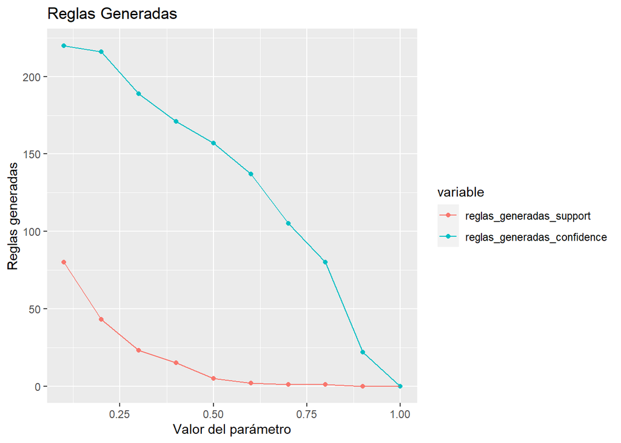

```r
g <- ggplot(
    melt(ejercicio4.df, id.vars = "parametro"),
    aes(x = parametro, y = value, color = variable)
  ) +
  geom_point() +
  geom_line() +
  xlim(0.1, 1) +
  labs(
    title = "Reglas Generadas",
    x = "Valor del parámetro",
    y = "Reglas generadas"
  )

# Mostramos la gráfica
g
```

**Apartado 5**

Para esto indicamos que en el *consecuente* de las reglas encontradas solo puede aparecer el sexo, a través del parámetro `rhs`.

```r
titanic.rules.sexo <- apriori(
  titanic.trans,
  appearance = list(
    rhs = c("sexo=hombre", "sexo=mujer"),
    default = "lhs"
  ),
  control = list(verbose = FALSE)
)

# Mostramos las reglas encontradas por pantalla
inspect(titanic.rules.sexo)
```

```
##      lhs                       rhs             support confidence  coverage     lift count
## [1]  {superviviente=No}     => {sexo=hombre} 0.5004794  0.8446602 0.5925216 1.340914   522
## [2]  {clase=segunda,
##       superviviente=No}     => {sexo=hombre} 0.1294343  0.9246575 0.1399808 1.467911   135
## [3]  {superviviente=No,
##       embarque=Southampton} => {sexo=hombre} 0.4074784  0.8483034 0.4803452 1.346698   425
## [4]  {superviviente=No,
##       edad=Adult}           => {sexo=hombre} 0.4439118  0.8621974 0.5148610 1.368755   463
## [5]  {clase=segunda,
##       superviviente=No,
##       embarque=Southampton} => {sexo=hombre} 0.1169703  0.9172932 0.1275168 1.456220   122
## [6]  {clase=segunda,
##       superviviente=No,
##       edad=Adult}           => {sexo=hombre} 0.1236817  0.9214286 0.1342282 1.462785   129
## [7]  {clase=tercera,
##       superviviente=No,
##       edad=Adult}           => {sexo=hombre} 0.2310642  0.8033333 0.2876318 1.275307   241
## [8]  {superviviente=No,
##       edad=Adult,
##       embarque=Southampton} => {sexo=hombre} 0.3624161  0.8669725 0.4180249 1.376335   378
## [9]  {clase=segunda,
##       superviviente=No,
##       edad=Adult,
##       embarque=Southampton} => {sexo=hombre} 0.1112176  0.9133858 0.1217641 1.450017   116
## [10] {clase=tercera,
##       superviviente=No,
##       edad=Adult,
##       embarque=Southampton} => {sexo=hombre} 0.1965484  0.8200000 0.2396932 1.301766   205
```

## Ejercicio 5

**Partiendo del del conjunto de reglas generado por el algoritmo apriori en el ejercicio 4.1.**

**1- Selecciona el conjunto de reglas que permitan determinar si se sobrevive a partir de la ciudad de embarque ¿Cuántas reglas se han seleccionado?.**

**2. Del conjunto anterior, selecciona las reglas con una confianza superior al 0.83.**

**3. Calcula el índice gini, hyperlift e hyperConfidence. Agrégalos al conjunto de reglas `titanic.rules` y muestra por pantalla, para cada índice, las 5 reglas que lo tengan más alto.**

**4. Genera diferentes conjuntos de reglas para las reglas no redundantes y maximales.**

**5. Genera los conjuntos de los itemsets frecuentes maximales y cerrados.**

**Apartado 1**

Utilizamos la función `subset()`.

```r
titanic.rules.sub1 <- subset(
  titanic.rules,
  subset = lhs %pin% "embarque" & rhs %pin% "superviviente")

# Mostramos las reglas encontradas por pantalla
inspectDT(titanic.rules.sub1)
```

|  | LHS | RHS | support | confidence | coverage | lift | count |
| --- | --- | --- | --- | --- | --- | --- | --- |
| [40] | {sexo=hombre,embarque=Southampton} | {superviviente=No} | 0.407478427612656 | 0.822050290135397 | 0.49568552253116 | 1.38737613691136 | 425 |
| [49] | {clase=segunda,sexo=hombre,embarque=Southampton} | {superviviente=No} | 0.116970278044104 | 0.865248226950355 | 0.135186960690316 | 1.46028139273337 | 122 |
| [61] | {clase=tercera,sexo=hombre,embarque=Southampton} | {superviviente=No} | 0.232981783317354 | 0.84083044982699 | 0.277085330776606 | 1.41907145496691 | 243 |
| [72] | {sexo=hombre,edad=Adult,embarque=Southampton} | {superviviente=No} | 0.36241610738255 | 0.849438202247191 | 0.426653883029722 | 1.43359877822625 | 378 |
| [76] | {clase=segunda,sexo=hombre,edad=Adult,embarque=Southampton} | {superviviente=No} | 0.111217641418984 | 0.928 | 0.119846596356663 | 1.56618770226537 | 116 |
| [80] | {clase=tercera,sexo=hombre,edad=Adult,embarque=Southampton} | {superviviente=No} | 0.196548418024928 | 0.854166666666667 | 0.230105465004794 | 1.44157901833873 | 205 |

Como se puede ver, se han encontrado **6 reglas**.

**Apartado 2**

Del conjunto anterior, seleccionamos aquellas con una confianza superior a ‘0.83’.

```r
titanic.rules.sub2 <- subset(
  titanic.rules.sub1,
  subset = confidence > 0.83
  )

# Mostramos por pantalla
inspectDT(titanic.rules.sub2)
```

|  | LHS | RHS | support | confidence | coverage | lift | count |
| --- | --- | --- | --- | --- | --- | --- | --- |
| [49] | {clase=segunda,sexo=hombre,embarque=Southampton} | {superviviente=No} | 0.116970278044104 | 0.865248226950355 | 0.135186960690316 | 1.46028139273337 | 122 |
| [61] | {clase=tercera,sexo=hombre,embarque=Southampton} | {superviviente=No} | 0.232981783317354 | 0.84083044982699 | 0.277085330776606 | 1.41907145496691 | 243 |
| [72] | {sexo=hombre,edad=Adult,embarque=Southampton} | {superviviente=No} | 0.36241610738255 | 0.849438202247191 | 0.426653883029722 | 1.43359877822625 | 378 |
| [76] | {clase=segunda,sexo=hombre,edad=Adult,embarque=Southampton} | {superviviente=No} | 0.111217641418984 | 0.928 | 0.119846596356663 | 1.56618770226537 | 116 |
| [80] | {clase=tercera,sexo=hombre,edad=Adult,embarque=Southampton} | {superviviente=No} | 0.196548418024928 | 0.854166666666667 | 0.230105465004794 | 1.44157901833873 | 205 |

**Apartado 3**

Añadimos dichas medidas al conjunto de medidas ya registradas en el conjunto de reglas, mediante la siguiente instrucción:

```r
quality(titanic.rules) <- cbind(
  quality(titanic.rules),
  interestMeasure(
    titanic.rules,
    c("gini", "hyperLift", "hyperConfidence"),
    titanic.trans
  )
)
```

Mostramos para cada índice, las cinco reglas que lo tengan más alto.

```r
inspect(head(sort(titanic.rules, by = "gini"), n=5))
```

```
##     lhs                       rhs                  support confidence  coverage     lift count       gini hyperLift hyperConfidence
## [1] {superviviente=No}     => {sexo=hombre}      0.5004794  0.8446602 0.5925216 1.340914   522 0.13411633  1.282555               1
## [2] {sexo=hombre,
##      edad=Adult}           => {superviviente=No} 0.4439118  0.8180212 0.5426654 1.380576   463 0.12067567  1.307910               1
## [3] {superviviente=No,
##      edad=Adult}           => {sexo=hombre}      0.4439118  0.8621974 0.5148610 1.368755   463 0.11452259  1.300562               1
## [4] {sexo=hombre,
##      embarque=Southampton} => {superviviente=No} 0.4074784  0.8220503 0.4956855 1.387376   425 0.10356401  1.307692               1
## [5] {sexo=hombre,
##      edad=Adult,
##      embarque=Southampton} => {superviviente=No} 0.3624161  0.8494382 0.4266539 1.433599   378 0.09823658  1.340426               1
```

```r
inspect(head(sort(titanic.rules, by = "hyperLift"), n=5))
```

```
##     lhs                       rhs                  support confidence  coverage     lift count       gini hyperLift hyperConfidence
## [1] {clase=primera,
##      sexo=mujer}           => {superviviente=Si} 0.1208054  0.9618321 0.1255992 2.360449   126 0.08828364  1.909091               1
## [2] {clase=primera,
##      sexo=mujer,
##      edad=Adult}           => {superviviente=Si} 0.1131352  0.9672131 0.1169703 2.373655   118 0.08300316  1.903226               1
## [3] {clase=segunda,
##      sexo=hombre,
##      edad=Adult,
##      embarque=Southampton} => {superviviente=No} 0.1112176  0.9280000 0.1198466 1.566188   116 0.03064972  1.348837               1
## [4] {clase=segunda,
##      sexo=hombre,
##      edad=Adult}           => {superviviente=No} 0.1236817  0.9148936 0.1351870 1.544068   129 0.03249057  1.343750               1
## [5] {sexo=hombre,
##      edad=Adult,
##      embarque=Southampton} => {superviviente=No} 0.3624161  0.8494382 0.4266539 1.433599   378 0.09823658  1.340426               1
```

```r
inspect(head(sort(titanic.rules, by = "hyperConfidence"), n=5))
```

```
##     lhs                       rhs                  support confidence  coverage     lift count       gini hyperLift hyperConfidence
## [1] {superviviente=No}     => {sexo=hombre}      0.5004794  0.8446602 0.5925216 1.340914   522 0.13411633  1.282555               1
## [2] {clase=segunda,
##      superviviente=No}     => {sexo=hombre}      0.1294343  0.9246575 0.1399808 1.467911   135 0.02828003  1.298077               1
## [3] {clase=primera,
##      sexo=mujer}           => {superviviente=Si} 0.1208054  0.9618321 0.1255992 2.360449   126 0.08828364  1.909091               1
## [4] {clase=tercera,
##      sexo=hombre}          => {superviviente=No} 0.2770853  0.8304598 0.3336529 1.401569   289 0.05669605  1.290179               1
## [5] {superviviente=No,
##      embarque=Southampton} => {sexo=hombre}      0.4074784  0.8483034 0.4803452 1.346698   425 0.08817240  1.272455               1
```

**Apartado 4**

Generamos diferentes conjuntos de reglas para las no redundantes y maximales.

Reglas maximales:

```r
titanic.rules.sub3 <- titanic.rules[is.maximal(titanic.rules)]

# Por pantalla
inspectDT(titanic.rules.sub3)
```

|  | LHS | RHS | support | confidence | coverage | lift | count | gini | hyperLift | hyperConfidence |
| --- | --- | --- | --- | --- | --- | --- | --- | --- | --- | --- |
| [13] | {clase=primera,embarque=Cherbourg} | {edad=Adult} | 0.11601150527325 | 0.9453125 | 0.122722914669223 | 1.12168479806598 | 121 | 0.00294239284628398 | 1.04310344827586 | 0.999839657876973 |
| [14] | {superviviente=Si,embarque=Cherbourg} | {edad=Adult} | 0.103547459252157 | 0.818181818181818 | 0.126558005752637 | 0.970834626124728 | 108 | 0.00017507727539226 | 0.9 | 0.168438976825051 |
| [26] | {clase=primera,sexo=hombre} | {edad=Adult} | 0.13326941514861 | 0.920529801324503 | 0.144774688398849 | 1.09227825117344 | 139 | 0.00204762268593531 | 1.02205882352941 | 0.998042217069739 |
| [27] | {clase=primera,embarque=Southampton} | {edad=Adult} | 0.131351869606903 | 0.907284768211921 | 0.144774688398849 | 1.07656201734361 | 137 | 0.00140954179635547 | 1.00735294117647 | 0.990183292903647 |
| [57] | {clase=primera,superviviente=Si,sexo=mujer} | {edad=Adult} | 0.11313518696069 | 0.936507936507937 | 0.120805369127517 | 1.11123751738086 | 118 | 0.00241514335238294 | 1.02608695652174 | 0.999317231223982 |
| [58] | {clase=primera,sexo=mujer,edad=Adult} | {superviviente=Si} | 0.11313518696069 | 0.967213114754098 | 0.116970278044104 | 2.37365477338476 | 118 | 0.0830031622990188 | 1.90322580645161 | 1 |
| [59] | {superviviente=Si,sexo=mujer,embarque=Southampton} | {edad=Adult} | 0.150527325023969 | 0.835106382978723 | 0.180249280920422 | 0.990916902669862 | 157 | 2.57690732079763e-05 | 0.928994082840237 | 0.329207060060976 |
| [73] | {clase=segunda,superviviente=No,sexo=hombre,embarque=Southampton} | {edad=Adult} | 0.111217641418984 | 0.950819672131147 | 0.116970278044104 | 1.12821947444003 | 116 | 0.00309348001219548 | 1.04504504504505 | 0.99990158565802 |
| [74] | {clase=segunda,superviviente=No,sexo=hombre,edad=Adult} | {embarque=Southampton} | 0.111217641418984 | 0.89922480620155 | 0.123681687440077 | 1.20088536858927 | 116 | 0.00638709790884696 | 1.08411214953271 | 0.999995047608625 |
| [75] | {clase=segunda,superviviente=No,edad=Adult,embarque=Southampton} | {sexo=hombre} | 0.111217641418984 | 0.913385826771654 | 0.12176414189837 | 1.45001737796474 | 116 | 0.0222822444823222 | 1.26086956521739 | 0.999999999999988 |

[output cut: 5 more lines]

Reglas no redundantes:

```r
titanic.rules.sub4 <- titanic.rules[!is.redundant(titanic.rules)]

# Por pantalla
inspectDT(titanic.rules.sub4)
```

|  | LHS | RHS | support | confidence | coverage | lift | count | gini | hyperLift | hyperConfidence |
| --- | --- | --- | --- | --- | --- | --- | --- | --- | --- | --- |
| [1] | {} | {edad=Adult} | 0.842761265580057 | 0.842761265580057 | 1 | 1 | 879 |  | 1 | 0 |
| [2] | {embarque=Cherbourg} | {edad=Adult} | 0.171620325982742 | 0.844339622641509 | 0.203259827420901 | 1.00187284006268 | 179 | 1.27108720796021e-06 | 0.947089947089947 | 0.48033353122733 |
| [3] | {clase=segunda} | {embarque=Southampton} | 0.222435282837967 | 0.888888888888889 | 0.250239693192713 | 1.18708208849054 | 232 | 0.0130997081439248 | 1.11004784688995 | 0.999999999850665 |
| [4] | {clase=segunda} | {edad=Adult} | 0.216682646212848 | 0.865900383141762 | 0.250239693192713 | 1.02745631355729 | 226 | 0.000357402293505144 | 0.974137931034483 | 0.862183066126795 |
| [5] | {clase=primera} | {edad=Adult} | 0.250239693192713 | 0.925531914893617 | 0.270373921380633 | 1.09821363735386 | 261 | 0.00507746772498366 | 1.044 | 0.999998223080553 |
| [8] | {superviviente=No} | {sexo=hombre} | 0.500479386385427 | 0.844660194174757 | 0.592521572387344 | 1.34091412865186 | 522 | 0.134116330842455 | 1.28255528255528 | 1 |
| [9] | {superviviente=No} | {embarque=Southampton} | 0.480345158197507 | 0.810679611650485 | 0.592521572387344 | 1.0826361523066 | 501 | 0.0111353319074455 | 1.04592901878914 | 0.999999974767231 |
| [10] | {superviviente=No} | {edad=Adult} | 0.514860977948226 | 0.868932038834951 | 0.592521572387344 | 1.0310536023946 | 537 | 0.00199187761112982 | 1.00561797752809 | 0.996497674943087 |
| [11] | {sexo=hombre} | {edad=Adult} | 0.542665388302972 | 0.861491628614916 | 0.629913710450623 | 1.0222249927706 | 566 | 0.00119426430112626 | 0.998236331569665 | 0.980560145119832 |
| [12] | {embarque=Southampton} | {edad=Adult} | 0.632790028763183 | 0.845070422535211 | 0.748801534036433 | 1.0027399894246 | 660 | 3.1789715754349e-05 | 0.985074626865672 | 0.604868288740299 |

[output cut: 39 more lines]

**Apartado 5**

Generamos los conjuntos de itemsets frecuentes maximales y cerrados.

Conjunto de itemsets frecuentes maximales:

```r
titanic.eclat.sub1 <- titanic.eclat[is.maximal(titanic.eclat)]

# Por pantalla
inspectDT(titanic.eclat.sub1)
```

|  | items | support | count |
| --- | --- | --- | --- |
| [1] | {edad=Child,embarque=Southampton} | 0.109300095877277 | 114 |
| [2] | {clase=tercera,edad=Child} | 0.101629913710451 | 106 |
| [3] | {clase=primera,edad=Adult,embarque=Cherbourg} | 0.11601150527325 | 121 |
| [4] | {superviviente=Si,edad=Adult,embarque=Cherbourg} | 0.103547459252157 | 108 |
| [6] | {sexo=hombre,embarque=Cherbourg} | 0.109300095877277 | 114 |
| [9] | {clase=segunda,superviviente=No,sexo=hombre,edad=Adult,embarque=Southampton} | 0.111217641418984 | 116 |
| [24] | {clase=segunda,superviviente=Si} | 0.11025886864813 | 115 |
| [25] | {clase=primera,superviviente=Si,sexo=mujer,edad=Adult} | 0.11313518696069 | 118 |
| [29] | {clase=primera,sexo=hombre,edad=Adult} | 0.13326941514861 | 139 |
| [30] | {clase=primera,edad=Adult,embarque=Southampton} | 0.131351869606903 | 137 |

[output cut: 6 more lines]

Conjunto de itemsets frecuentes cerrados:

```r
titanic.eclat.sub2 <- titanic.eclat[is.closed(titanic.eclat)]

# Por panatalla
inspectDT(titanic.eclat.sub2)
```

|  | items | support | count |
| --- | --- | --- | --- |
| [1] | {edad=Child,embarque=Southampton} | 0.109300095877277 | 114 |
| [2] | {clase=tercera,edad=Child} | 0.101629913710451 | 106 |
| [3] | {clase=primera,edad=Adult,embarque=Cherbourg} | 0.11601150527325 | 121 |
| [4] | {superviviente=Si,edad=Adult,embarque=Cherbourg} | 0.103547459252157 | 108 |
| [5] | {edad=Adult,embarque=Cherbourg} | 0.171620325982742 | 179 |
| [6] | {sexo=hombre,embarque=Cherbourg} | 0.109300095877277 | 114 |
| [7] | {superviviente=Si,embarque=Cherbourg} | 0.126558005752637 | 132 |
| [8] | {clase=primera,embarque=Cherbourg} | 0.122722914669223 | 128 |
| [9] | {clase=segunda,superviviente=No,sexo=hombre,edad=Adult,embarque=Southampton} | 0.111217641418984 | 116 |
| [10] | {clase=segunda,superviviente=No,sexo=hombre,edad=Adult} | 0.123681687440077 | 129 |

[output cut: 77 more lines]